# Shared Variance and Relative Importance

How much does each predictor really explain, and does the answer depend on how we ask?

Author

Supplementary note

Published

September 8, 2026

## 1 Why this note exists

The paper’s stepwise table (Model 1 to Model 5) reports coefficients and *t*-values for each predictor. It is tempting to read those *t*-values as a ranking of importance, and an earlier draft of section 4.2 did exactly that. That reading is not safe, for a reason worth setting out carefully.

In a multiple regression, each coefficient describes a predictor’s **unique** contribution: the association that remains once every other predictor is held constant. Where predictors are uncorrelated, unique contribution and total contribution are the same thing and nothing is lost. Where predictors are correlated, a large part of the variance they explain is **shared** between them, and the model has no way to attribute that shared part to one variable rather than another. It simply goes unallocated. A variable that overlaps heavily with the others will therefore show a modest *t*-value even when it accounts for a great deal of the outcome on its own.

Our three main predictors overlap a good deal, so this is not a hypothetical concern. This note quantifies it: it reports what each predictor explains on its own, what every combination of predictors explains, and how the shared variance is apportioned when we use a method designed for that purpose. It then asks the question that actually matters — whether the paper’s conclusions depend on which measure we choose.

The analysis sample is 12,208 school-years, the same rows used for the paper’s models, restricted to complete cases so that every model below is fitted on identical data.

## 2 How much do the predictors overlap?

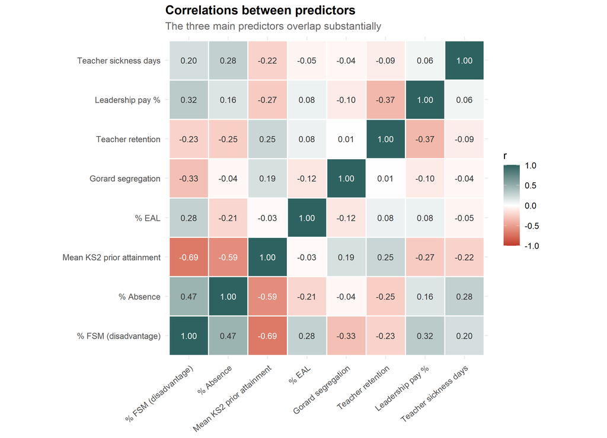

Figure 1: Correlations between the model’s continuous predictors. Strong off-diagonal values mean shared variance that a multiple regression cannot attribute to one variable rather than another.

Table 1: Correlations between the three main predictors.

| Pair | r |
| --- | --- |
| % FSM and mean KS2 | -0.690 |
| % Absence and mean KS2 | -0.591 |
| % FSM and % Absence | +0.467 |

Schools with more disadvantaged intakes have markedly lower prior attainment, and schools with higher absence also have lower prior attainment. These are not nuisance correlations to be controlled away; they are the structure of the problem. But they do mean that a large share of the variance in attainment is explained by these variables *jointly*, and any claim about which one matters most has to say how the joint part is being handled.

## 3 What each predictor explains on its own

The simplest question: fit each predictor alone against attainment, and record the $R^2$. This is the *total* association, including everything the variable shares with the others.

Table 2: Each predictor fitted on its own. This is total explanatory power, sharing included.

| Predictor | R² | Variance explained |
| --- | --- | --- |
| Mean KS2 prior attainment | 0.586 | 58.6% |
| % Absence | 0.498 | 49.8% |
| % FSM (disadvantage) | 0.393 | 39.3% |
| Admissions policy | 0.278 | 27.8% |
| Teacher retention | 0.098 | 9.8% |
| Leadership pay % | 0.072 | 7.2% |
| Teacher sickness days | 0.068 | 6.8% |
| Gorard segregation | 0.018 | 1.8% |
| % EAL | 0.007 | 0.7% |

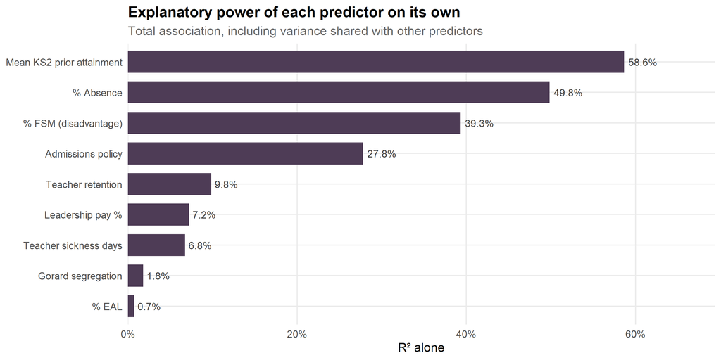

Figure 2: Variance in school-level Attainment 8 explained by each predictor on its own.

On this measure prior attainment leads, absence follows, and disadvantage is third. Note how different this is from the *t*-values in the paper’s Model 3, where absence appears strongest and disadvantage weakest by a wide margin. The gap between the two pictures is precisely the shared variance.

## 4 Every combination of the three main predictors

The table below fits all eight possible subsets of disadvantage, absence and prior attainment, and reports both the model $R^2$ and how each coefficient and *t*-value moves as its companions are added.

Table 3: All 8 subsets of the three main predictors, fitted on identical rows. Watch the FSM coefficient shrink as its companions enter.

| Model | R² | FSM β | FSM t | Abs β | Abs t | KS2 β | KS2 t |
| --- | --- | --- | --- | --- | --- | --- | --- |
| (intercept only) | 0.000 | — | — | — | — | — | — |
| FSM | 0.393 | -0.201 | -88.944 | — | — | — | — |
| Absence | 0.498 | — | — | -0.486 | -110.108 | — | — |
| KS2 | 0.586 | — | — | — | — | 0.054 | 131.539 |
| FSM + Absence | 0.612 | -0.122 | -59.649 | -0.364 | -82.819 | — | — |
| FSM + KS2 | 0.605 | -0.060 | -23.936 | — | — | 0.045 | 80.860 |
| Absence + KS2 | 0.685 | — | — | -0.268 | -61.821 | 0.038 | 85.049 |
| FSM + Absence + KS2 | 0.696 | -0.047 | -21.054 | -0.259 | -60.490 | 0.031 | 58.243 |

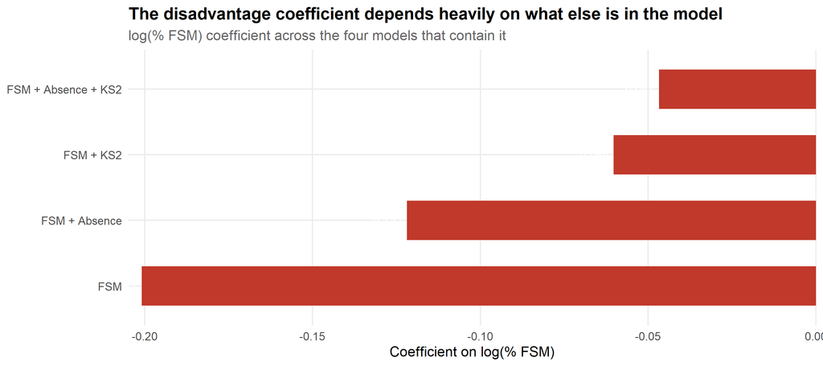

Figure 3: How the disadvantage coefficient changes as the other predictors are added. Each bar is a model; the coefficient more than halves once absence and prior attainment are present.

This is the shared-variance problem made visible. Disadvantage on its own carries a coefficient of about −0.20; with absence and prior attainment alongside it, that falls to roughly −0.05. Nothing about the schools has changed — only what else the model is being told.

Which of those numbers is “the effect of disadvantage” depends entirely on the question. If you want the total association between a school’s intake composition and its results, the first is closer. If you want the association that remains between two schools with the same absence and the same prior attainment, the last is closer. The paper needs the second, because its question is what happens if you change intake composition while everything else stays as it is — but it should not then describe that number as the importance of disadvantage in general, and section 3.2 now says so explicitly.

## 5 Apportioning the shared variance

Neither “$R^2$ alone” nor “the coefficient in the full model” is a complete answer. The first hands each variable all of the shared variance; the second hands it none. The standard resolution is to average over every possible order in which the variables could enter: a variable’s contribution is computed when it enters first, second and third, and these are averaged. This is the Shapley value from cooperative game theory (Shapley 1953), known in this context as the LMG decomposition after Lindeman et al. (1980) and set out for regression by Grömping (2007).

The values reported here are computed directly in this document rather than taken from a package: for three predictors by averaging over all six orders of entry, and for the nine-predictor model by summing weighted marginal contributions over the subset lattice. The `relaimpo` package (Grömping 2007) implements the same quantity as `calc.relimp(type = "lmg")`, and reproducing the nine-predictor decomposition through it returns identical figures — the largest discrepancy is of order $10^{-14}$, which is floating-point noise. Computing it inline keeps the cohort-by-cohort and outcome-by-outcome variants used later in this note on a single code path.

Table 4: Shapley (LMG) decomposition of the three-predictor model. Each variable’s contribution is averaged over all six orders of entry, so the shared variance is split rather than assigned arbitrarily.

| Predictor | R² alone | Shapley R² | Share of explained variance |
| --- | --- | --- | --- |
| Mean KS2 prior attainment | 0.586 | 0.290 | 41.7% |
| % Absence | 0.498 | 0.249 | 35.8% |
| % FSM (disadvantage) | 0.393 | 0.157 | 22.5% |

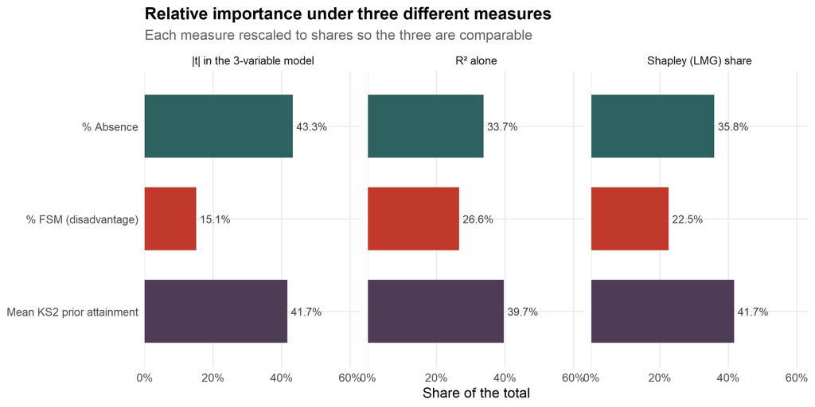

Figure 4: The three predictors ranked three ways. Prior attainment and absence swap places depending on the measure; disadvantage is last on all three.

The ranking of the top two **does** depend on the measure. By *t*-value, absence leads; by explanatory power alone and by the Shapley decomposition, prior attainment leads. This is exactly why the paper no longer rests any claim on the *t*-value ordering.

What does not change is the position of disadvantage: **last under all three measures**, whether it is credited with all of the shared variance, none of it, or an even split. The paper’s substantive argument depends only on that, and it is robust to the choice.

## 6 All nine predictors

The same decomposition across the full fixed-effect specification. With nine predictors there are $2^9 = 512$ subsets and $9! = 362{,}880$ orderings, so the Shapley values are computed from the subset lattice rather than by enumerating permutations — the two are mathematically identical, but the first is tractable.

Table 5: Shapley (LMG) decomposition across all nine fixed-effect predictors, computed over all 512 subsets.

| Predictor | R² alone | Shapley R² | Share |
| --- | --- | --- | --- |
| Mean KS2 prior attainment | 0.586 | 0.226 | 31.8% |
| % Absence | 0.498 | 0.199 | 28.0% |
| % FSM (disadvantage) | 0.393 | 0.127 | 17.9% |
| Admissions policy | 0.278 | 0.079 | 11.2% |
| Teacher retention | 0.098 | 0.029 | 4.1% |
| Teacher sickness days | 0.068 | 0.017 | 2.5% |
| Leadership pay % | 0.072 | 0.017 | 2.4% |
| % EAL | 0.007 | 0.011 | 1.5% |
| Gorard segregation | 0.018 | 0.005 | 0.7% |

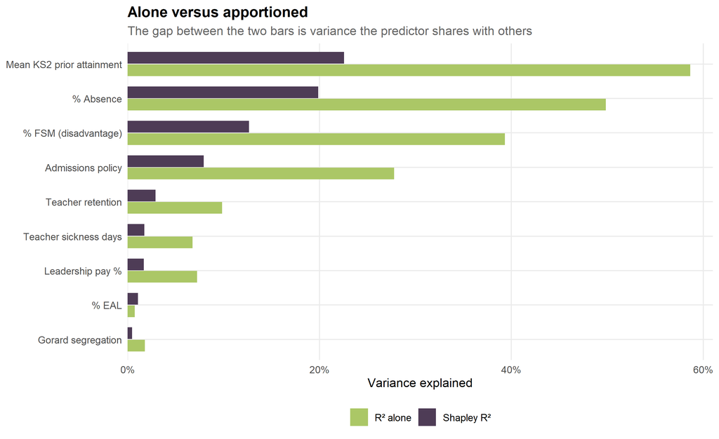

The sum of the Shapley values is 0.709, which by construction equals the $R^2$ of the full nine-predictor model — the decomposition allocates all of the explained variance and none of it twice.

## 7 What this means for the paper

Three conclusions, in order of how much they matter.

**The importance ranking of the top two predictors is method-dependent, and the paper should not assert one.** Section 4.2 previously ranked the three by *t*-value and called absence the most important. That has been rewritten: it now reports the *t*-values as measures of precision, states plainly that they cannot rank importance where predictors are correlated, and gives the explanatory-power and Shapley figures alongside. Section 4.3, which uses standardised coefficients from the full model, already placed prior attainment first; the two sections no longer contradict one another.

**The paper’s argument does not depend on the choice.** Concentrations of disadvantage rank last on every measure tried here. The claim the paper actually makes — that disadvantage concentration is a weak lever relative to absence, and that an admissions policy built on it is unlikely to deliver the gains sought — is unaffected by how the shared variance is apportioned.

**Prior attainment is large but is not a lever.** The measures above rank *explanatory power*, not *actionability*. Prior attainment is the single largest source of variation on two of the three measures, but it is fixed for any cohort already in secondary school: it describes the intake a school receives, not something the school or its authority can change. Once it is set aside as intake rather than lever, absence is the largest factor remaining that is open to intervention — which is the distinction section 4.3 draws and the one on which the policy argument rests.

## 8 A caveat on all of this

Every measure here is descriptive. None of them licenses a causal reading, and the relative-importance literature is explicit that these decompositions apportion *variance explained*, not *effect* (Grömping 2007). Two predictors can share variance because one causes the other, because a third thing causes both, or because they are alternative measurements of the same underlying disadvantage — and no decomposition of an observational dataset can tell these apart. That prior attainment, absence and disadvantage overlap so heavily is itself the substantive finding: they are facets of a single structure, and the policy question is not which is “most important” but which of them can actually be moved.

## 9 Disadvantaged and non-disadvantaged pupils, taken separately

Everything above treats the school’s headline Attainment 8 — the average across all its pupils — as the outcome. That average is a mixture. A school with a high proportion of disadvantaged pupils scores lower partly because disadvantaged pupils score lower on average nationally, quite apart from anything happening inside the school. The published data lets us take the mixture apart: DfE reports Attainment 8 separately for the disadvantaged cohort (`ATT8SCR_FSM6CLA1A`) and the non-disadvantaged cohort (`ATT8SCR_NFSM6CLA1A`) in each school. Repeating the whole decomposition on each of these asks a sharper question — not “what explains a school’s average result” but “what explains how *these pupils* do here” — and the answers differ in ways that matter for the policy argument.

The comparison sample is 12,069 school-years, 139 fewer than the sample used above, and the all-pupil figures are recomputed on it throughout this section so that the three columns are like-for-like.

That exclusion is not random, and it matters enough to name. A school-year drops out when DfE suppresses one of the cohort figures because the cohort is too small to publish, which in practice means schools with very few disadvantaged pupils. The rows dropped here have a median disadvantage share of 3% against 25% in the retained sample, and a median Attainment 8 of 75 against 46; 100 of the 139 are selective schools. Removing them trims the extreme high-attainment, low-disadvantage corner of the distribution, and the effect on the all-pupil figures is not negligible: prior attainment alone rises from an $R^2$ of 0.586 in section 3 to 0.622 here, and absence from 0.498 to 0.543, while admissions policy falls from 0.278 to 0.260 as the selective category loses its most distinctive members. The all-pupil column below is the right comparator for the two cohort columns, but it is *not* interchangeable with the headline figures in sections 3 to 6, and the two sets should not be read across. None of the rankings change.

Table 6: The three outcomes on the common sample. Disadvantaged attainment is both lower and considerably more variable between schools.

| Outcome | Mean | SD between schools | SD of log |
| --- | --- | --- | --- |
| All pupils | 47.40 | 8.99 | 0.18 |
| Disadvantaged | 38.52 | 9.46 | 0.23 |
| Non-disadvantaged | 50.42 | 8.29 | 0.16 |

The average gap between the two cohorts within a school is 11.9 Attainment 8 points. The two subgroup scores correlate at 0.81 across schools: schools that do well by one cohort tend to do well by the other, but far from perfectly.

### 9.1 What each predictor explains, by cohort

Table 7: Each predictor fitted on its own against each of the three outcomes. Total association, sharing included.

| Predictor | All pupils | Disadvantaged | Non-disadvantaged |
| --- | --- | --- | --- |
| Mean KS2 prior attainment | 0.622 | 0.423 | 0.593 |
| % Absence | 0.543 | 0.479 | 0.489 |
| % FSM (disadvantage) | 0.415 | 0.126 | 0.315 |
| Admissions policy | 0.260 | 0.298 | 0.261 |
| Teacher retention | 0.113 | 0.049 | 0.112 |
| Leadership pay % | 0.076 | 0.025 | 0.069 |
| Teacher sickness days | 0.071 | 0.051 | 0.067 |
| Gorard segregation | 0.013 | 0.004 | 0.008 |
| % EAL | 0.008 | 0.077 | 0.014 |

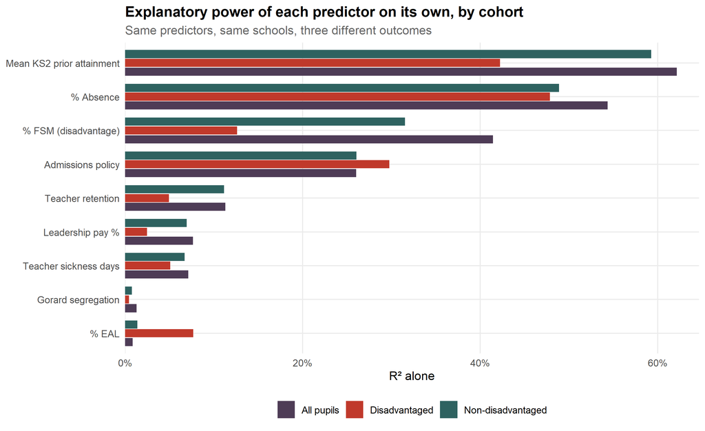

Two things stand out immediately.

**Prior attainment is a much weaker predictor of disadvantaged pupils’ results.** On its own it explains 59% of the variation in non-disadvantaged attainment but only 42% of the variation in disadvantaged attainment. Part of that is a measurement artefact — `ks2_c` is the school’s mean prior attainment across *all* pupils, so it describes the non-disadvantaged cohort more faithfully than the disadvantaged one — but the size of the gap is larger than that alone would suggest.

**Absence is the one predictor that holds up.** It explains 48% of disadvantaged attainment against 49% of non-disadvantaged attainment — almost the same. For the disadvantaged cohort it is the strongest single predictor in the set, ahead of prior attainment.

Note also that the proportion of disadvantaged pupils explains far less of disadvantaged pupils’ own attainment (13%) than it does of the headline average (41%). That discrepancy is the subject of the next section.

### 9.2 The disadvantage coefficient changes sign

Section 4 showed the coefficient on log(% FSM) shrinking from about −0.20 to −0.05 as absence and prior attainment were added. Repeating that exercise for each cohort produces something more dramatic.

Table 8: The coefficient on log(% FSM) across the four models that contain it, for each outcome. For disadvantaged pupils it does not merely shrink — it reverses.

| Model | FSM β | FSM t | R² |
| --- | --- | --- | --- |
| **All pupils** |  |  |  |
| FSM | -0.2069 | -92.4 | 0.415 |
| FSM + Absence | -0.1256 | -66.2 | 0.665 |
| FSM + KS2 | -0.0697 | -30.1 | 0.648 |
| FSM + Absence + KS2 | -0.0545 | -28.0 | 0.754 |
| **Disadvantaged** |  |  |  |
| FSM | -0.1400 | -41.7 | 0.126 |
| FSM + Absence | -0.0213 | -7.3 | 0.481 |
| FSM + KS2 | +0.0529 | +14.7 | 0.433 |
| FSM + Absence + KS2 | +0.0756 | +24.5 | 0.591 |
| **Non-disadvantaged** |  |  |  |
| FSM | -0.1568 | -74.6 | 0.315 |
| FSM + Absence | -0.0862 | -45.9 | 0.565 |
| FSM + KS2 | -0.0257 | -12.0 | 0.597 |
| FSM + Absence + KS2 | -0.0135 | -7.1 | 0.689 |

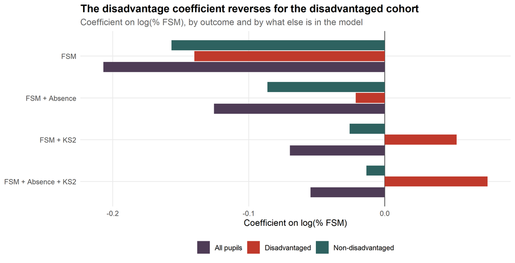

Figure 7: The disadvantage coefficient by cohort and specification. Conditional on absence and prior attainment, disadvantaged pupils do better in schools with more disadvantaged pupils, not worse.

Taken on its own, a higher share of disadvantaged pupils is associated with *lower* attainment for the disadvantaged cohort (β = -0.140). Hold absence and prior attainment constant and the sign flips to +0.076 — a large and precisely estimated positive association. Compare two schools with the same attendance and the same intake prior attainment, and the one with the *more* disadvantaged intake gets better results out of its disadvantaged pupils. For the non-disadvantaged cohort the coefficient stays negative throughout but collapses to -0.0135, close enough to zero to be of no practical consequence despite its significance.

This is not a statistical curiosity. It says that the headline association between intake composition and results — the association on which a composition-based admissions policy would rest — survives at the level of the school average but largely vanishes, or reverses, at the level of the pupils it is supposed to help.

### 9.3 Why the aggregate says something the cohorts do not

The reason is arithmetic, and worth making explicit. A school’s headline Attainment 8 is the FSM-weighted average of its two cohort scores:

$$\text{ATT8} \;=\; w \cdot \text{ATT8}_{\text{disadv}} \;+\; (1 - w) \cdot \text{ATT8}_{\text{non-disadv}}$$

where $w$ is the school’s share of disadvantaged pupils. Raising $w$ shifts weight onto the lower-scoring group and pulls the average down *even if neither cohort’s score changes at all*. Some of the headline FSM association is therefore pure mixing, with no schooling content whatsoever.

Fixing both cohort scores at their sample means and letting only $w$ vary reproduces an elasticity of -0.059 on log(% FSM), against the -0.207 actually observed. Roughly **29% of the raw disadvantage–attainment association is mechanical composition**, present before any question of school quality, teaching or peer effects arises. The remainder is shared with absence and prior attainment, which is what the rest of this note has been about.

### 9.4 Apportioning the shared variance, by cohort

Table 9: Shapley (LMG) decomposition of the three-predictor model, separately by cohort. Cells show the apportioned R² and, in brackets, its share of the three.

| Predictor | All pupils | Disadvantaged | Non-disadvantaged |
| --- | --- | --- | --- |
| % FSM (disadvantage) | 0.168 (22.3%) | 0.051 (8.6%) | 0.119 (17.3%) |
| % Absence | 0.278 (36.8%) | 0.296 (50.1%) | 0.251 (36.4%) |
| Mean KS2 prior attainment | 0.308 (40.9%) | 0.244 (41.3%) | 0.319 (46.3%) |

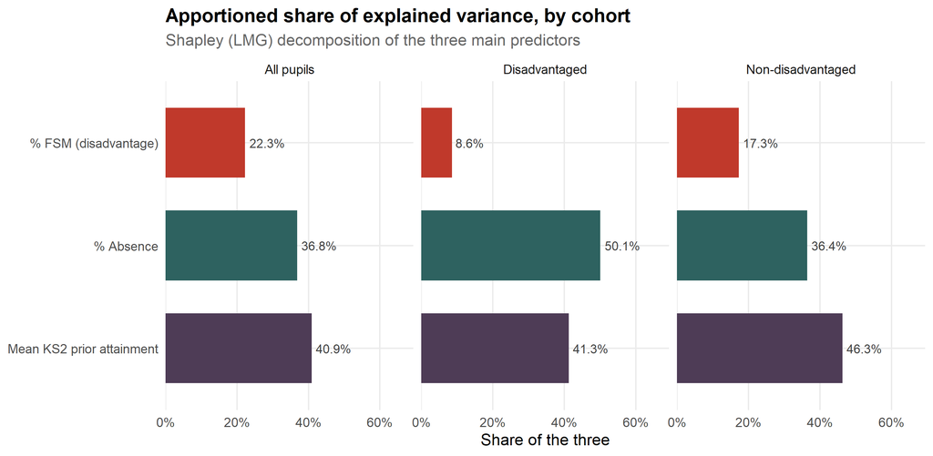

Figure 8: Shares of the explained variance in the three-predictor model, by cohort. Absence overtakes prior attainment for disadvantaged pupils and falls behind it for non-disadvantaged pupils.

For all pupils and for the non-disadvantaged cohort, prior attainment takes the largest share. For the disadvantaged cohort the order changes: absence takes 50.1% of the explained variance, more than prior attainment and more than five times the share taken by intake composition. Whatever measure is used, and for whichever cohort, disadvantage concentration comes last of the three.

### 9.5 All nine predictors, by cohort

Table 10: Shapley (LMG) shares across all nine fixed-effect predictors, by cohort. Each column sums to 100%; the R² being apportioned is given in the final row.

| Predictor | All pupils | Disadvantaged | Non-disadvantaged |
| --- | --- | --- | --- |
| Mean KS2 prior attainment | 31.6% | 26.9% | 35.0% |
| % Absence | 28.8% | 35.9% | 27.6% |
| % FSM (disadvantage) | 18.4% | 6.1% | 13.6% |
| Admissions policy | 9.8% | 17.4% | 11.4% |
| Teacher retention | 4.2% | 2.0% | 4.8% |
| Teacher sickness days | 2.5% | 2.2% | 2.6% |
| Leadership pay % | 2.4% | 0.8% | 2.4% |
| % EAL | 1.9% | 8.4% | 2.2% |
| Gorard segregation | 0.5% | 0.3% | 0.4% |
| Total R² apportioned | 0.771 | 0.635 | 0.711 |

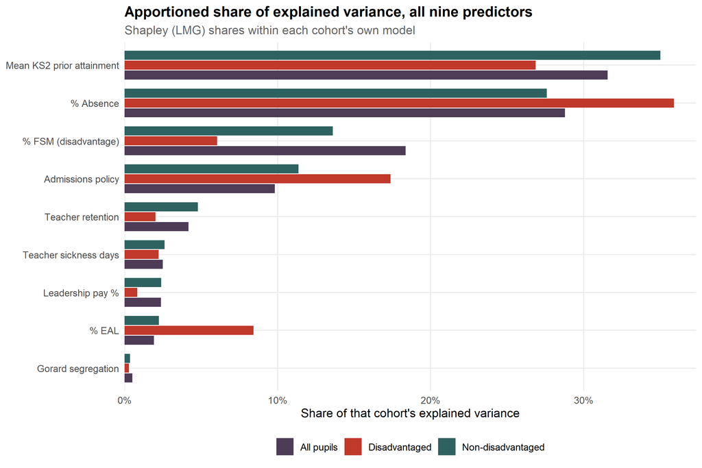

Figure 9: Apportioned share of explained variance across all nine predictors, by cohort. Admissions policy and EAL matter appreciably more for the disadvantaged cohort; prior attainment matters appreciably less.

The full model explains 0.771 of the variance in headline attainment and 0.711 for the non-disadvantaged cohort, but only 0.635 for the disadvantaged cohort. Structural school characteristics predict how advantaged pupils do considerably better than they predict how disadvantaged pupils do. The residual variation — what schools do, and how well they do it, over and above their intake and their attendance — is substantially larger for the pupils the policy is aimed at.

Two predictors are much more important for the disadvantaged cohort than for the others. Admissions policy takes 17.4% of the explained variance against 9.8% for all pupils, and EAL takes 8.4% against 1.9%. The EAL result is the familiar one that disadvantaged pupils with English as an additional language outperform disadvantaged pupils without it; the admissions result reflects the selective and highly-selective-area categories, where the small disadvantaged cohorts that do get in are unrepresentative of disadvantaged pupils generally. Neither is a lever in the sense the paper uses the word.

## 10 Synthesis: what holds across cohorts and what does not

Table 11: Rank of the three main predictors under each measure and for each cohort. 1 = largest.

| Measure | Outcome | % FSM (disadvantage) | % Absence | Mean KS2 prior attainment |
| --- | --- | --- | --- | --- |
| Absolute t in the 3-variable model | All pupils | 3 | 1 | 2 |
|  | Disadvantaged | 3 | 1 | 2 |
|  | Non-disadvantaged | 3 | 2 | 1 |
| R² alone | All pupils | 3 | 2 | 1 |
|  | Disadvantaged | 3 | 1 | 2 |
|  | Non-disadvantaged | 3 | 2 | 1 |
| Shapley (LMG) | All pupils | 3 | 2 | 1 |
|  | Disadvantaged | 3 | 1 | 2 |
|  | Non-disadvantaged | 3 | 2 | 1 |

### 10.1 Three things that hold everywhere

**Disadvantage concentration is never the leading factor.** Across three outcomes and three measures — nine combinations in all — the share of disadvantaged pupils in a school ranks last of the three main predictors in every one. It ranks last when it is credited with all of the variance it shares with the others, when it is credited with none of it, and when the shared part is split evenly. The paper’s central claim does not depend on which cohort is examined or on how the sharing is resolved.

**Absence is always the largest movable factor.** Prior attainment leads on two of the three outcomes, but it is a description of the intake rather than something a school or an authority can act on. Set it aside and absence is the largest remaining factor for all pupils, for disadvantaged pupils and for non-disadvantaged pupils alike. For the disadvantaged cohort it is the largest factor full stop.

**Shared variance is substantial in every case, so *t*-values remain unsafe as a ranking.** The gap between “$R^2$ alone” and “Shapley” that motivated this note is just as wide for both subgroups as it is for the headline outcome. As it happens, the *t*-value ordering agrees with the other two measures for both cohorts, and disagrees only for all pupils — the reverse of what one might expect. That agreement is a fact about this data rather than a reason to trust *t*-values: the predictors are just as correlated in the cohort models, the *t*-values still allocate none of the shared variance, and nothing in the method guarantees that the orderings will coincide. Where they happen to coincide it is luck, and section 4.2 of the paper should not lean on it.

### 10.2 Three things that differ

**Absence and prior attainment change places.** For non-disadvantaged pupils, prior attainment is comfortably the largest factor (46.3% of the explained variance against 36.4% for absence). For disadvantaged pupils the order reverses and absence becomes the dominant term (50.1% against 41.3%). Part of this is that `ks2_c` measures the whole intake rather than the disadvantaged part of it, and so tracks the non-disadvantaged cohort more closely. But the direction of the difference points the same way as the attendance literature: missed schooling costs disadvantaged pupils more, because they have less capacity to make the lost ground up outside school. This strengthens rather than weakens the paper’s case for attendance as the priority lever, since the lever bites hardest exactly where the gap is.

**The disadvantage coefficient changes sign between cohorts.** Conditional on absence and prior attainment, a more disadvantaged intake is associated with *better* results for disadvantaged pupils (+0.076) and with marginally worse results for non-disadvantaged pupils (-0.0135). The negative headline association is therefore not one effect operating on everyone: it is composition arithmetic, plus a very small negative association for the advantaged cohort, running against a positive association for the disadvantaged cohort. A policy that dispersed disadvantaged pupils into less disadvantaged schools would, on these figures, be moving them into settings where — attendance and prior attainment held equal — disadvantaged pupils do slightly worse rather than better. That is a more awkward result for composition-based admissions policy than the headline model alone suggests, and it is worth stating in the paper.

**Disadvantaged attainment is markedly less predictable.** The full nine-predictor model reaches an $R^2$ of 0.71 for the non-disadvantaged cohort but only 0.63 for the disadvantaged cohort, despite disadvantaged attainment varying *more* between schools (SD of log 0.23 against 0.16). More between-school variation, less of it accounted for: around 37% of the variation in how disadvantaged pupils do is not explained by any of the structural characteristics available here. Read optimistically that is headroom — school-level practice that the intake does not determine. Read cautiously it is a warning that the measurable characteristics of a school tell you least about the pupils the policy most wants to help.

### 10.3 Caveats specific to the subgroup analysis

Three limitations apply to this section over and above the general caveat in section 8.

*The prior-attainment measure is not cohort-specific.* `ks2_c` is the school’s mean KS2 score across all pupils, so it is a better proxy for the non-disadvantaged cohort’s starting point than for the disadvantaged cohort’s. Some of the apparent weakness of prior attainment in the disadvantaged column is measurement rather than substance, and the figure for a cohort-specific prior attainment measure would be higher. The direction of the difference is nonetheless likely to be right, since a cohort-specific measure would raise the disadvantaged prior-attainment figure without lowering the absence figure.

*The absence measure is likewise school-wide.* Overall absence and disadvantaged pupils’ own absence are strongly related but not identical, and disadvantaged absence is the higher of the two in almost every school. This makes the absence result for the disadvantaged cohort conservative if anything: a cohort-specific absence measure would be expected to strengthen it.

*Small cohorts are noisy.* Schools with few disadvantaged pupils produce disadvantaged Attainment 8 figures based on a handful of pupils, which inflates the between-school variance in that column and depresses its $R^2$. The models here are unweighted, so those schools carry the same weight as large ones. This is one plausible contributor to the lower explained variance for the disadvantaged cohort, and it should be borne in mind before reading the residual as headroom.

## 11 A combined figure: direction and apportioned magnitude together

The paper’s Figure 1 plots standardised coefficients for the three pupil groups. That shows *direction*, which matters — the sign on disadvantage concentration reverses between cohorts, and the reversal is one of the paper’s substantive findings — but a standardised coefficient is a partial quantity, so it understates any predictor that shares a lot of variance with the others. The Shapley shares computed above have the opposite property: they apportion the shared variance, but a variance decomposition has no sign.

Neither quantity is dispensable, and neither can be made to carry the other’s information. The figure below therefore shows both, on a shared vertical axis, with predictors ordered by apportioned share.

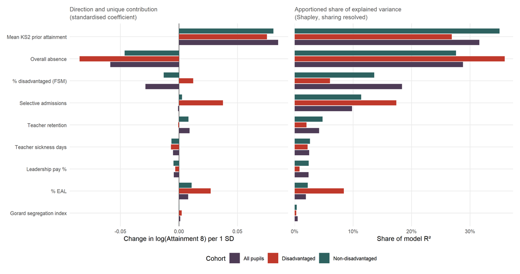

Figure 10: Relative importance of each predictor of school-level Attainment 8, by pupil group. The left panel gives the standardised coefficient from the multilevel model, which carries the direction of each association but only its unique contribution. The right panel gives the Shapley share of explained variance, which apportions the variance predictors share but has no sign. Predictors are ordered by Shapley share for all pupils. The two measures answer different questions - one about unique contribution, the other about total contribution with the shared variance divided between predictors - but they agree on the leading pair in every pupil group: mean KS2 prior attainment leads for all pupils and for non-disadvantaged pupils, and overall absence leads for disadvantaged pupils. Disadvantage concentration ranks third on both panels for all pupils and for non-disadvantaged pupils, and fifth for disadvantaged pupils.

Reading the two panels together gives the paper’s argument in one view.

**Absence is the largest factor a school can act on.** Prior attainment is larger still for two of the three groups, on both panels, but it describes the intake a school receives rather than anything it can change for a cohort already on roll. Set it aside and absence leads everywhere — and for disadvantaged pupils it is the largest term outright, on both panels.

**The two panels agree on the ordering, which is not guaranteed.** The measures answer different questions - one about unique contribution, one about total contribution with the sharing split - and there is nothing in either method that forces them to coincide. Here they do: prior attainment leads for all pupils and for the non-disadvantaged, absence for the disadvantaged, on both panels. That agreement is worth more than either panel alone, because the obvious objection to a ranking drawn from partial coefficients is that it ignores the shared variance, and apportioning that variance does not change the answer. It is the *t*-values, reported in section 4.2, that disagree - ranking absence above prior attainment for all pupils - and that is precisely why they should not be used to rank correlated predictors.

A note on construction. The standardised coefficients are taken from the multilevel models the paper fits, so the left panel reports exactly the quantity Figure 1 reports now. The Shapley shares are computed by OLS over all 512 subsets of the nine fixed effects: with `lmer()` the lattice would need 1,536 multilevel fits and is not practical, and the ordering is in any case governed by the fixed part. Both panels use the same school-years, restricted to rows where all three cohort outcomes are published.

## References

Grömping, Ulrike. 2007. “Relative Importance for Linear Regression in R: The Package relaimpo.” *Journal of Statistical Software* 17 (1): 1–27. https://doi.org/10.18637/jss.v017.i01.

Lindeman, Richard H., Peter F. Merenda, and Ruth Z. Gold. 1980. *Introduction to Bivariate and Multivariate Analysis*. Scott, Foresman.

Shapley, Lloyd S. 1953. “A Value for n-Person Games.” In *Contributions to the Theory of Games, Volume II*, edited by Harold W. Kuhn and Albert W. Tucker, vol. 28, 28. Annals of Mathematics Studies. Princeton University Press. https://doi.org/10.1515/9781400881970-018.